# Section 2: Grammar of Graphics

```r
library(palmerpenguins)
library(tidyverse)
penguins
```

```
## # A tibble: 344 × 8
##    species island    bill_length_mm bill_depth_mm flipper_length_mm body_mass_g
##    <fct>   <fct>              <dbl>         <dbl>             <int>       <int>
##  1 Adelie  Torgersen           39.1          18.7               181        3750
##  2 Adelie  Torgersen           39.5          17.4               186        3800
##  3 Adelie  Torgersen           40.3          18                 195        3250
##  4 Adelie  Torgersen           NA            NA                  NA          NA
##  5 Adelie  Torgersen           36.7          19.3               193        3450
##  6 Adelie  Torgersen           39.3          20.6               190        3650
##  7 Adelie  Torgersen           38.9          17.8               181        3625
##  8 Adelie  Torgersen           39.2          19.6               195        4675
##  9 Adelie  Torgersen           34.1          18.1               193        3475
## 10 Adelie  Torgersen           42            20.2               190        4250
## # … with 334 more rows, and 2 more variables: sex <fct>, year <int>
```

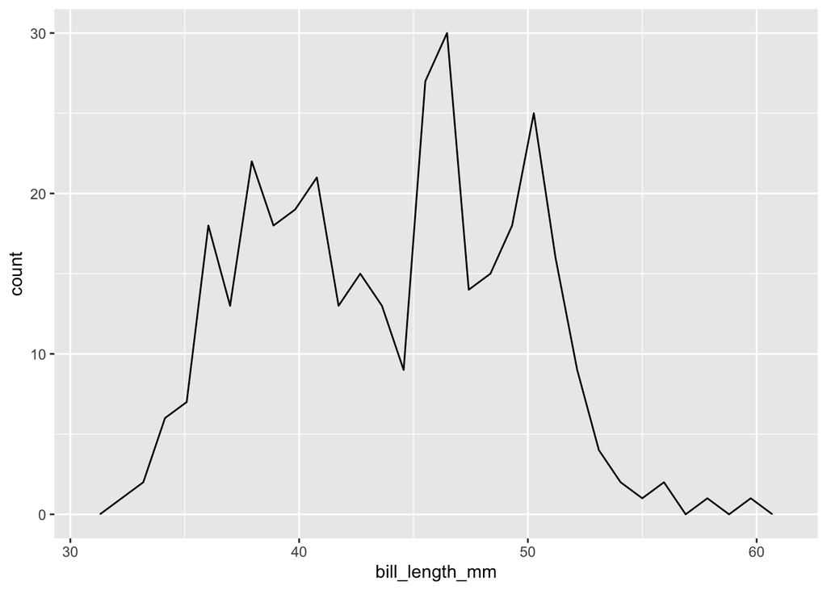

```r
## single quantitative frequency plot
ggplot(data = penguins, aes(x = bill_length_mm)) +
  geom_freqpoly()
```

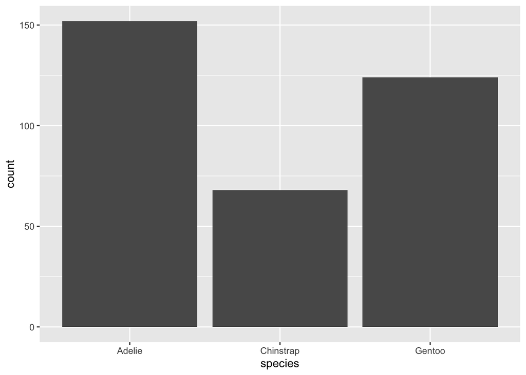

```r
## single categorical barplot
ggplot(data = penguins, aes(x = species)) +
  geom_bar()
```

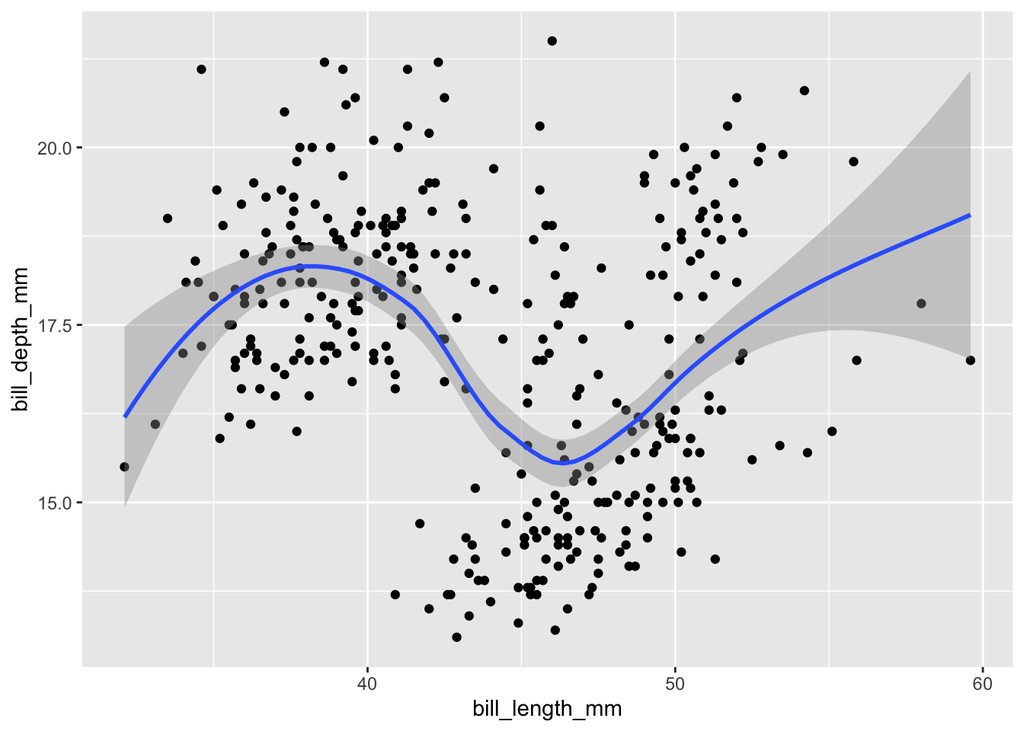

```r
## two quant scatterplot
ggplot(data = penguins, aes(x = bill_length_mm, y = bill_depth_mm)) +
  geom_point() +
  geom_smooth()
```

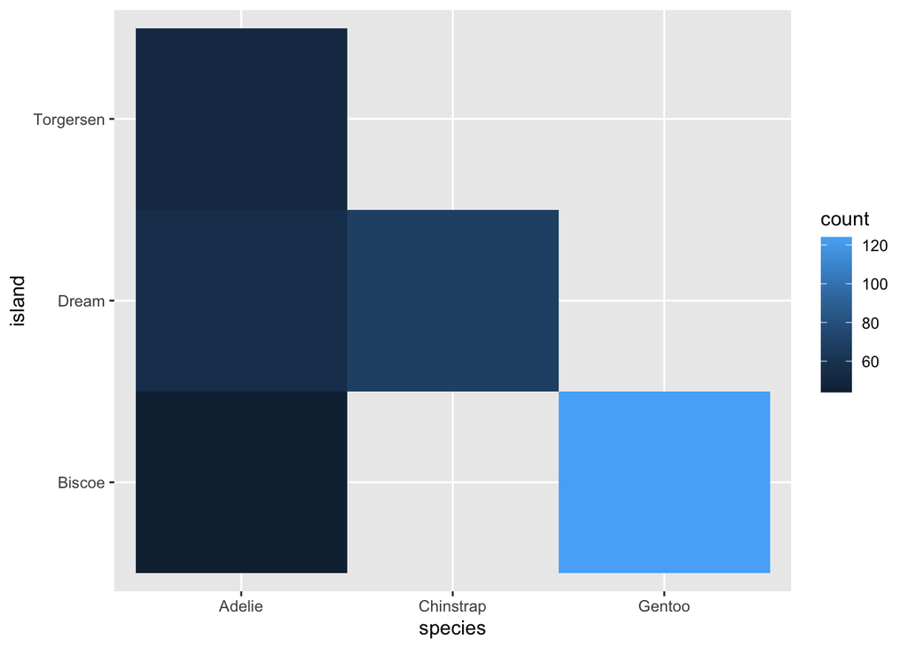

```r
## two cat heatmap
ggplot(data = penguins, aes(x = species, y = island)) +
  geom_bin_2d()
```

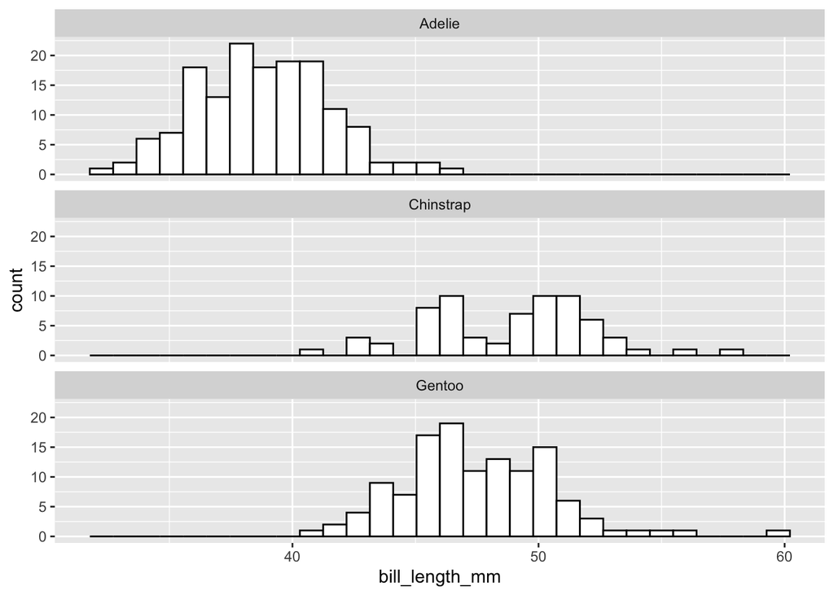

```r
ggplot(data = penguins, aes(x = bill_length_mm)) +
  geom_histogram(colour = "black", fill = "white") +
  facet_wrap(~ species, ncol = 1)
```

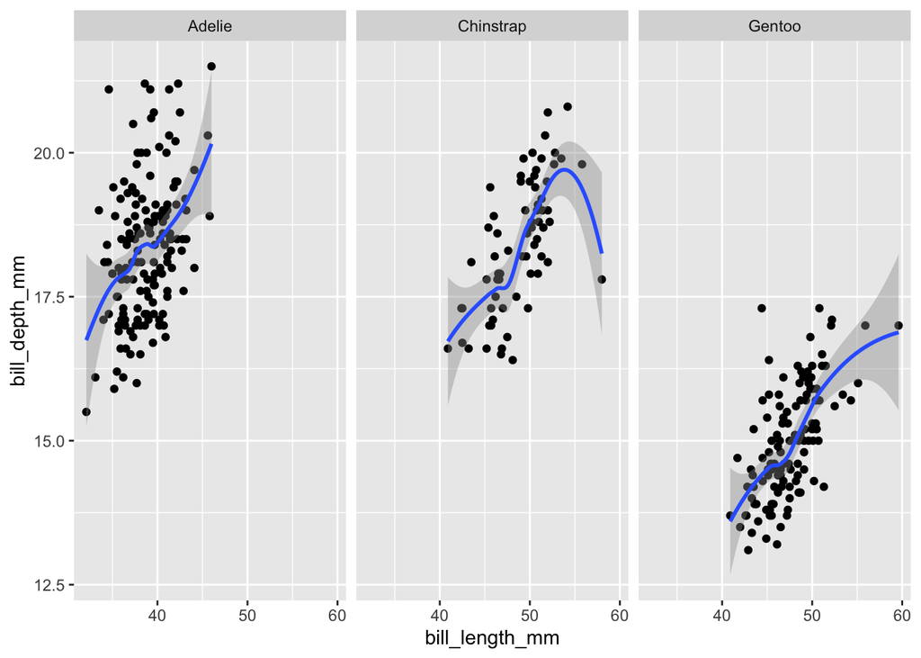

```r
ggplot(data = penguins, aes(x = bill_length_mm, y = bill_depth_mm)) +
  geom_point() +
  geom_smooth() +
  facet_wrap(~ species)
```

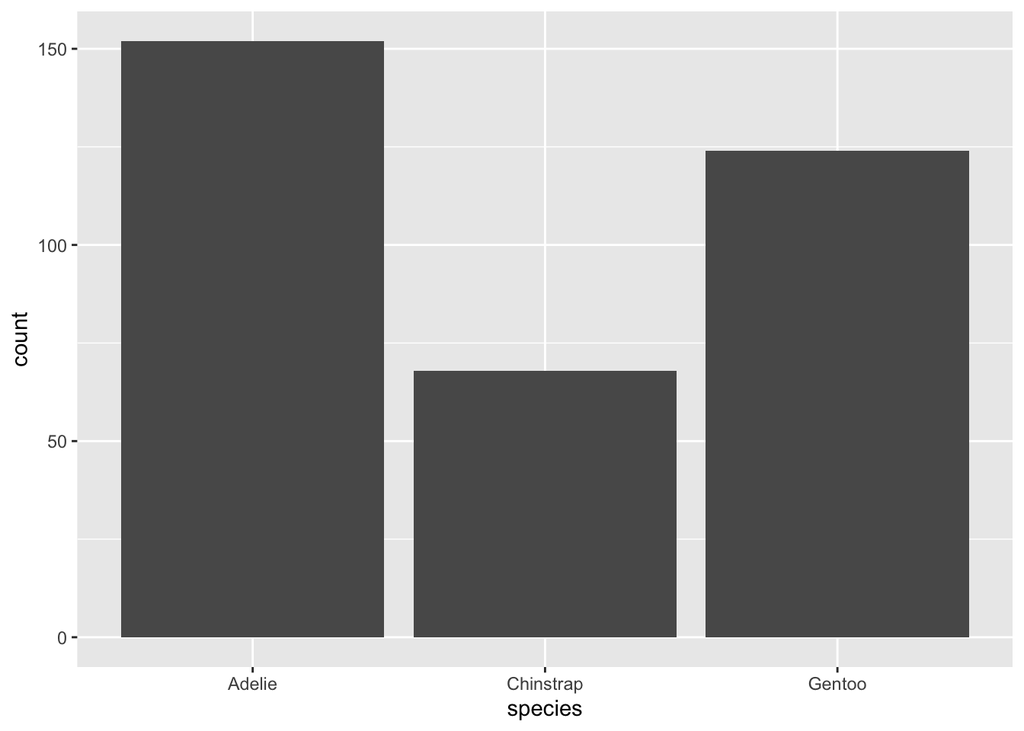

```r
ggplot(data = penguins, aes(x = species)) +
  geom_bar(stat = "count") ## don't need stat = "count" because it's the default.
```

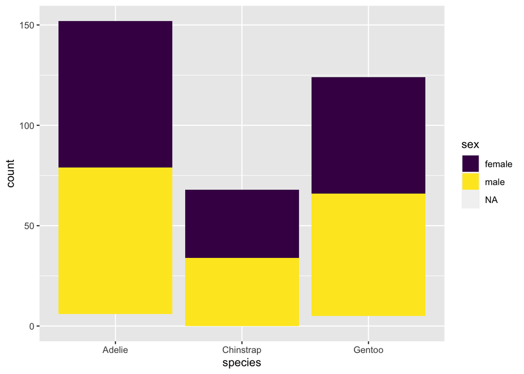

```r
ggplot(data = penguins, aes(x = species, fill = sex)) +
  geom_bar(position = "stack") + ## don't need "stacked" because it's default
  scale_fill_viridis_d()
```

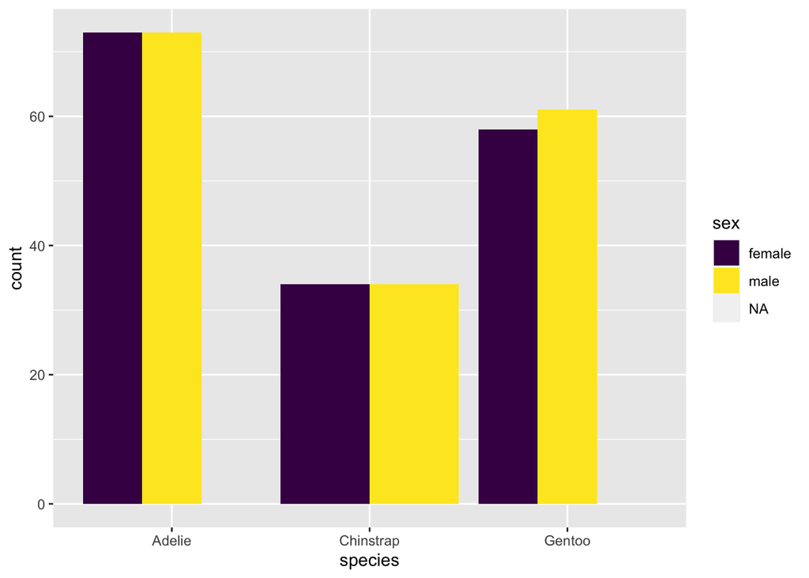

```r
ggplot(data = penguins, aes(x = species, fill = sex)) +
  geom_bar(position = "dodge") + ## don't need "stacked" because it's default
  scale_fill_viridis_d()
```

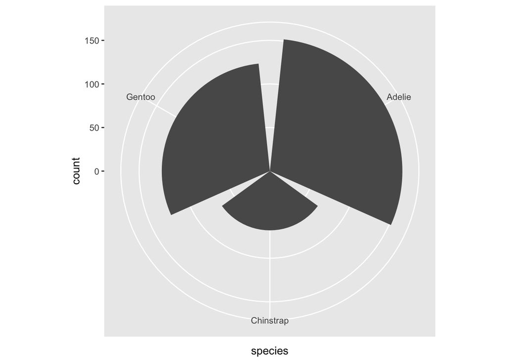

```r
ggplot(data = penguins, aes(x = species)) +
  geom_bar() +
  coord_polar()
```

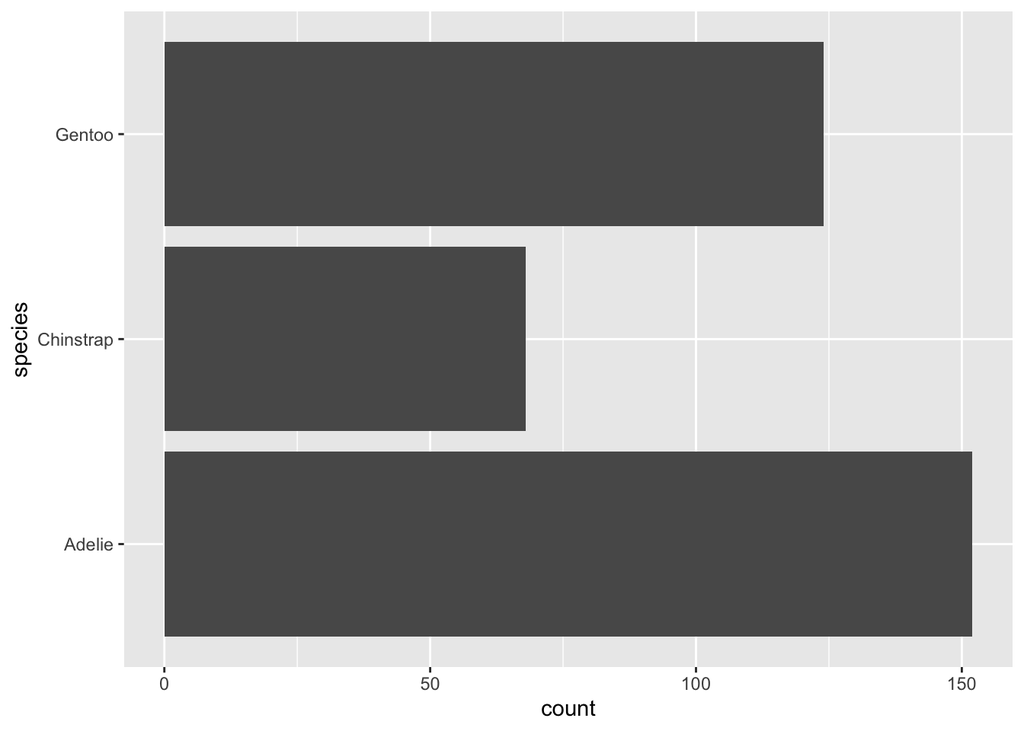

```r
ggplot(data = penguins, aes(x = species)) +
  geom_bar() +
  coord_flip()
```

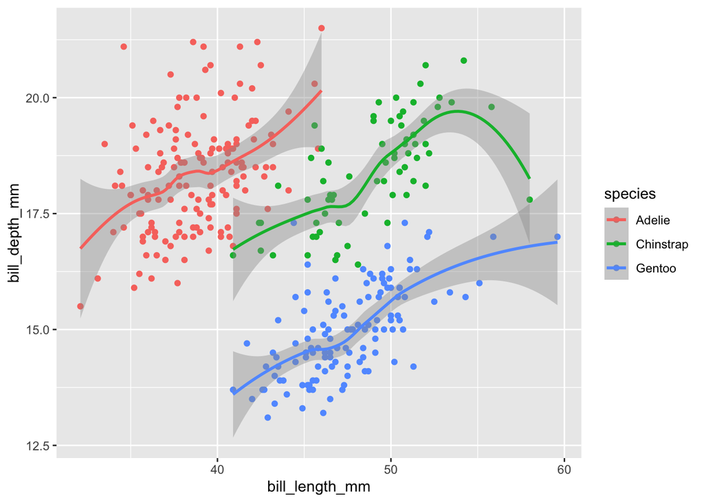

```r
ggplot(data = penguins, aes(x = bill_length_mm, y = bill_depth_mm,
                            colour = species)) +
  geom_point() +
  geom_smooth()
```

## Exercise 1.

In the above plots, we skipped the final “two variable” combination: one quantitative variable and one categorical variable. Create either a side-by-side boxplot or side-by-side violin plot of a quantitative and a categorical variable in the penguins data set.

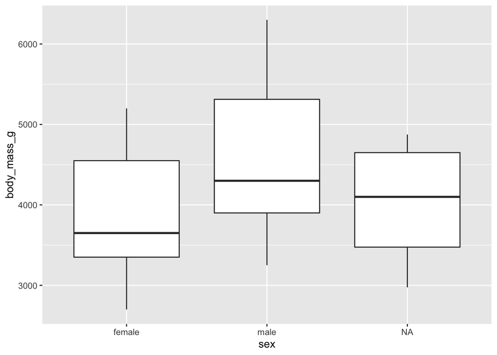

```r
ggplot(data = penguins, aes(x = sex, y = body_mass_g)) + geom_boxplot()
```

## Exercise 2.

Modify the frequency plot made with geom_freqpoly() to use colour in two different ways:

change the colour of the line to any colour that R knows. A list of some colours can be found at this link.

add a colour asethetic to make three different frequency lines, one for each species of penguin.

Hint: recall that only aesthetic mappings (variables) go inside aes(). Of (a) or (b), which one is an aesthetic mapping?

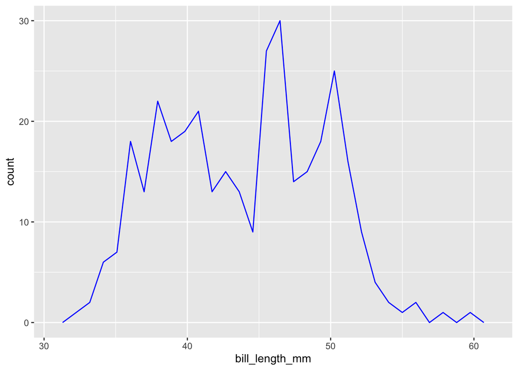

```r
ggplot(data = penguins, aes(x = bill_length_mm)) +
  geom_freqpoly(colour = "blue")
```

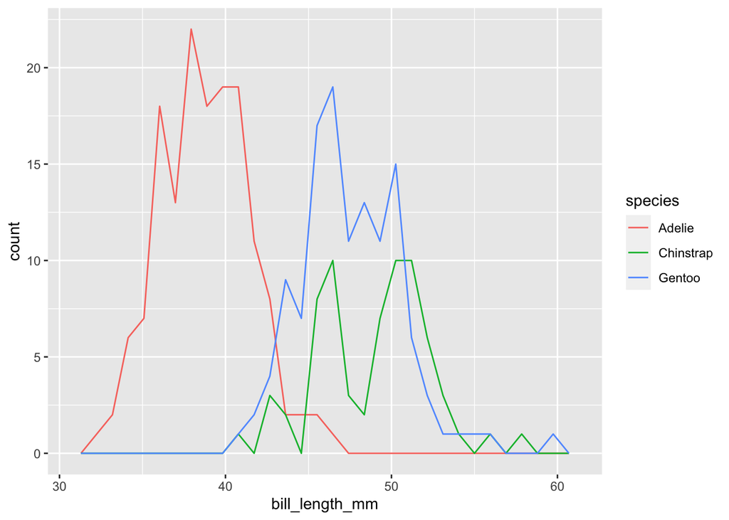

```r
ggplot(data = penguins, aes(x = bill_length_mm, colour = species)) +
  geom_freqpoly()
```

## Exercise 3.

Thus far, we have only plotted one or two variables at a time. Recall that one way to construct a plot of three different variables is to use colour. Modify the scatterplot so that the points are coloured by species.

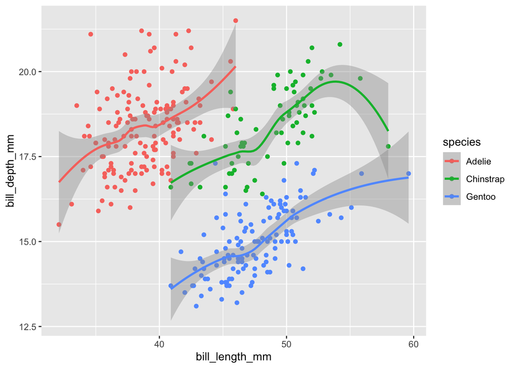

```r
ggplot(data = penguins, aes(x = bill_length_mm, y = bill_depth_mm, colour = species)) +
  geom_point() +
  geom_smooth()
```

## Exercise 4.

Recall that aes() aesthetics specified within the ggplot() function directly are called global aesthetics because every other GEOM will use them (unless specifically overridden) while aes() specified within a particular GEOM are called local aesthetics because only that particular GEOM will use them.

Modify the scatterplot and smoother so that

the points are coloured by species, but there is only one smoother instead of three.

there are three different coloured smoothers (one for each species) but the points are all the same colour.

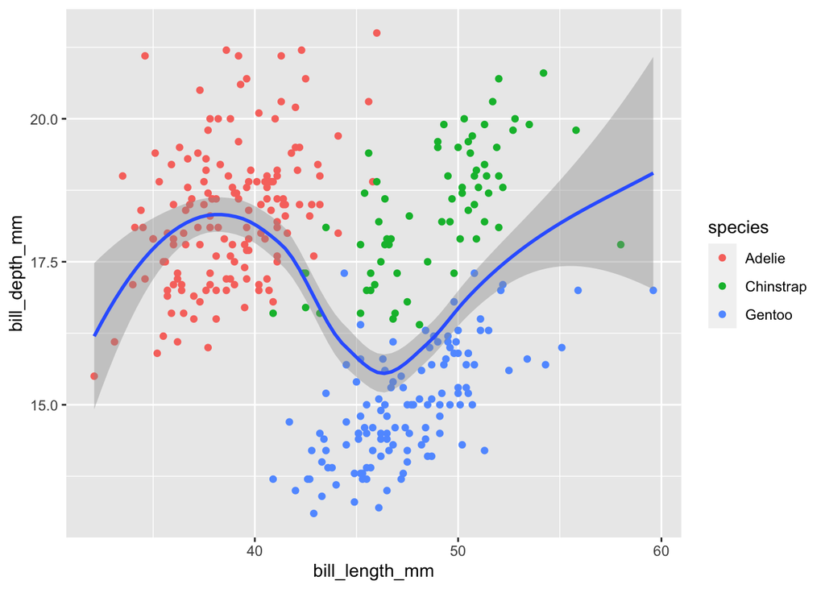

```r
ggplot(data = penguins, aes(x = bill_length_mm, y = bill_depth_mm)) +
  geom_point(aes(colour = species)) +
  geom_smooth()
```

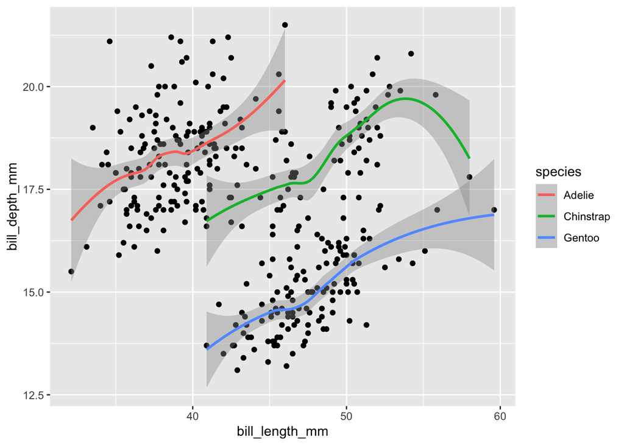

```r
ggplot(data = penguins, aes(x = bill_length_mm, y = bill_depth_mm)) +
  geom_point() +
  geom_smooth(aes(colour = species))
```

## Section 2.3

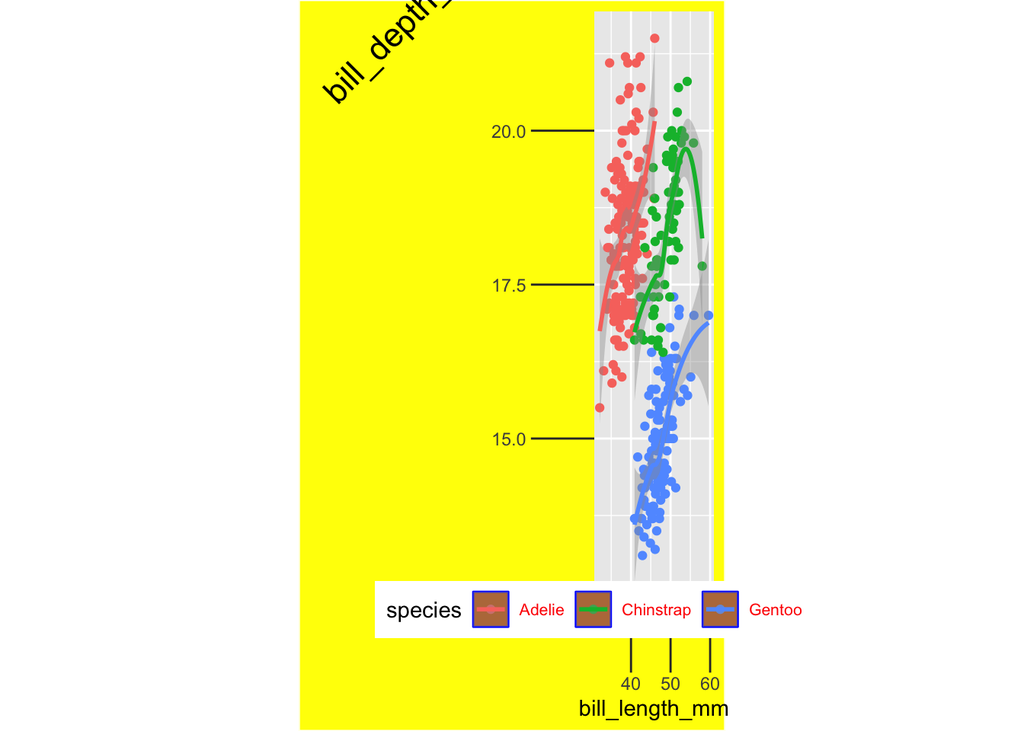

```r
ggplot(data = penguins, aes(x = bill_length_mm, y = bill_depth_mm,
                            colour = species)) +
  geom_point() +
  geom_smooth() +
  theme(plot.background = element_rect(fill = "yellow"), axis.ticks.length = unit(1.1, "cm"), legend.key = element_rect(fill = "darkorange3", colour = "blue"), legend.text = element_text(size = 8, colour = "red"), axis.title.y = element_text(size = rel(1.5), angle = 45), legend.position = c(0,0), legend.direction = "horizontal", aspect.ratio = 5)
```